# Parallel Processing Methods

Within R

Elizabeth King

Kevin Middleton

## Parallel Processing

- Monte Carlo methods are often computationally intensive
  - Many iterations
  - Often low memory usage
- Iterations are well suited to parallelization
  - Run sets of iterations on each core
  - Often get time close to 1 / n cores

## Local and Remote Computers

- Your computer likely has at least 4 cores
- Clusters located elsewhere (remote) often have hundreds to thousands of compute cores
  - e.g., the Lewis/Hellbender clusters at Mizzou

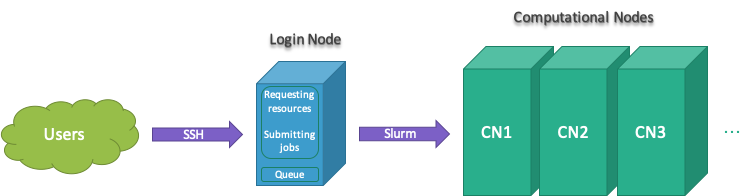

## Resources for Using Remote Computers

- [Software Carpentry](https://software-carpentry.org/lessons/)
- [RSS Help Pages](https://docs.rnet.missouri.edu/)
- [High-Performance and Parallel Computing with R](https://cran.r-project.org/web/views/HighPerformanceComputing.html)
- Many packages have functions that can use parallelization

## Introduction to Parallelization in R

1. Within a single R script
   - Base R: `parallel`
     - [parallely](https://parallelly.futureverse.org/)
   - foreach and `%dopar%` from `doParallel`
   - [future](https://www.futureverse.org/) and [furrr](https://furrr.futureverse.org/)
2. Using bash to run many R scripts via a scheduler (e.g., SLURM)

## Non-parallel

```r
MM <- read_excel("Data/Jackals.xlsx")

obs <- MM |> filter(Sex == "F") |> summarize(m = mean(Mandible)) |> pull(m) -
  MM |> filter(Sex == "M") |> summarize(m = mean(Mandible)) |> pull(m)

set.seed(3850234)

nreps <- 1e4
diffs <- numeric(length = nreps)
diffs[1] <- obs

for (ii in 2:nreps) {
  Rand_Sex <- sample(MM$Sex)
  diffs[ii] <- mean(MM$Mandible[Rand_Sex == "F"]) -
    mean(MM$Mandible[Rand_Sex == "M"])
}

# Two-tailed test
round(mean(abs(diffs) >= abs(diffs[1])), 4)
```

**1**

Setting different seeds for iterations

**2**

Splitting up iterations

**3**

Keeping and combining the output

```
[1] 0.0025
```

## Timing code in R

- `Sys.time()`
  - `t0 <- Sys.time()`
  - `Sys.time() - t0`
- `tictoc` package
  - `tic()`
  - `toc()`
- [bench](https://bench.r-lib.org/) and [microbenchmark](https://cran.r-project.org/web/packages/microbenchmark/index.html) packages

## Is it worth parallelizing?

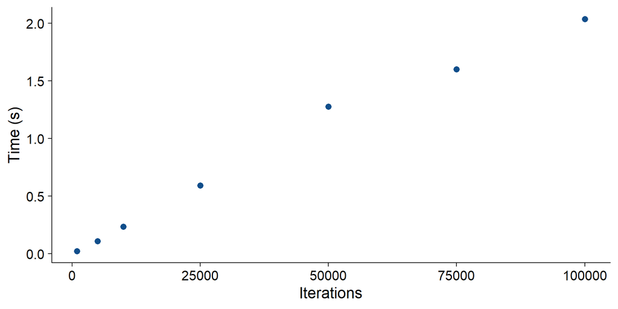

## `parallely`

```r
library(parallel)
library(parallelly)
(ncores <- parallelly::availableCores(omit = 1))
```

```
system
    19
```

```r
cl <- makeClusterPSOCK(rep("localhost", times = ncores),
                       dryrun = FALSE)
print(cl)
```

```
Socket cluster with 19 nodes where 19 nodes are on host 'localhost' (R version 4.3.3 (2024-02-29 ucrt), platform x86_64-w64-mingw32)
```

```r
# Other code goes here
```

Manually stop the cluster:

```r
stopCluster(cl)
```

## Converting a loop for parallelization

Notice that we don’t use `ii` in the function. It’s there for “accounting” later on.

```r
rand_diffs <- function(ii, MM) {
  Rand_Sex <- sample(MM$Sex)
  diffs <- mean(MM$Mandible[Rand_Sex == "F"]) -
    mean(MM$Mandible[Rand_Sex == "M"])
  return(diffs)
}

rand_diffs(1, MM)
```

```
[1] -2.4
```

```r
rand_diffs(1, MM)
```

```
[1] 2
```

```r
rand_diffs(1, MM)
```

```
[1] 1.8
```

## `lapply()`: Apply a function to a list or vector

The sequence 1 to 10 is passed as the first argument to the function

```r
lapply(seq_len(10), FUN = rand_diffs, MM = MM) |>
  as.numeric()
```

```
 [1]  1.0 -1.0 -1.2 -2.4  3.4  1.0 -1.6  0.2  0.6 -0.2
```

## Parallelizing `lapply()`

`mclapply()` and `parLapply()`

- Manually start and stop the cluster
- Tend to the random number generator

OS differences

- Linux & MacOS: `mclapply()`
- Windows: `parLapply()`

## `mclapply()`

```r
if (Sys.info()[['sysname']] != "Windows") {
  RNGkind("L'Ecuyer-CMRG")
  set.seed(123, "L'Ecuyer")

  mclapply(seq_len(10), FUN = rand_diffs, MM = MM,
           mc.set.seed = TRUE,
           mc.cores = ncores) |> as.numeric()
  mclapply(seq_len(10), FUN = rand_diffs, MM = MM,
           mc.set.seed = TRUE,
           mc.cores = ncores) |> as.numeric()
}
```

**1**

Set up a parallel-friendly random number generator

```r
if (Sys.info()[['sysname']] != "Windows") {
  RNGkind("Mersenne-Twister")
  mclapply(seq_len(10), FUN = rand_diffs, MM = MM,
           mc.set.seed = TRUE,
           mc.cores = ncores) |> as.numeric()
}
```

**2**

Reset to the default R random number generator

## Compare timings

```r
if (Sys.info()[['sysname']] != "Windows") {
  tic()
  x <- lapply(seq_len(1e6), FUN = rand_diffs, MM = MM) |> as.numeric()
  toc()

  tic()
  x <- mclapply(seq_len(1e6), FUN = rand_diffs, MM = MM,
                mc.set.seed = TRUE,
                mc.cores = ncores) |> as.numeric()
  toc()
}
```

## The futureverse

- More information: https://www.futureverse.org/ (Bengtsson 2021)
- Unification of parallelization for R
  - No windows vs. non-windows code differences
- “Drop in” replacements for
  - `lapply()` $\rightarrow$ future_lapply() (`future.apply` package)
  - `map()` $\rightarrow$ `future_map()` (`furrr` package)

## `purrr` and `furrr`

- `purrr::map_` family of functions
- `furrr::future_map_` analogues of `map_`
- `plan()` to setup how to the analysis will run
  - Easily switch back and forth between parallel and non-parallel (sequential)
  - Defaults to sequential
  - Works well with Windows (other parallelization methods often don’t)

## `purrr` and `furrr`

```r
map_dbl(.x = seq_len(10),
        .f = rand_diffs,
        MM = MM)
```

```
 [1]  2.8  5.2 -3.0  2.4  1.6 -2.6  2.0 -3.8  3.4 -1.2
```

```r
future_map_dbl(.x = seq_len(10),
               .f = rand_diffs,
               MM = MM,
               .options = furrr_options(seed = TRUE))
```

```
 [1] -0.8 -3.4 -0.4 -0.6 -3.0 -2.2  0.8  1.0 -1.2 -0.4
```

`.options = furrr_options(seed = TRUE)` handles setting the random number generator

## Parallelization with `furrr`

```r
plan(multisession, workers = ncores)

future_map_dbl(.x = seq_len(10), .f = rand_diffs, MM = MM,
               .options = furrr_options(seed = TRUE))
```

```
 [1]  0.0 -2.0  1.4 -0.2  3.6 -2.0  0.0  1.6  1.2 -3.0
```

Back to sequential evaluation:

```r
plan(sequential)
future_map_dbl(.x = seq_len(10), .f = rand_diffs, MM = MM,
               .options = furrr_options(seed = TRUE))
```

```
 [1]  3.2 -3.0  1.2 -1.6 -1.8  1.2 -0.4 -0.8  0.6 -4.2
```

## How much faster?

```r
plan(multisession, workers = ncores)

tic()
x <- future_map_dbl(.x = seq_len(1e6), .f = rand_diffs, MM = MM,
                    .options = furrr_options(seed = TRUE))
toc()
```

```
14.22 sec elapsed
```

```r
tic()
plan(sequential)
x <- future_map_dbl(.x = seq_len(1e6), .f = rand_diffs, MM = MM,
                    .options = furrr_options(seed = TRUE))
toc()
```

```
30.17 sec elapsed
```

## References

Bengtsson, H. 2021. [A Unifying Framework for Parallel and Distributed Processing in R Using Futures](https://doi.org/10.32614/rj-2021-048). *R Journal* 13:208. The R Foundation.